# Assignment 3

## Introduction

In the previous assignment we looked at data from GEO Accession GSE31729, which is associated with the paper “Lack of effect in desensitization with intravenous immunoglobulin and rituximab in highly-sensitized patients” by Akalin et al. This dataset contains gene expression profiles of blood samples gathered with Affymetrix Human Gene 1.0 ST Array of transplant patients, and it is trying to determine the effect of a combined treatment of intravenous immunoglobulin & rituximab on highly sensitized patients (the desired effect would be a desensitization, which would make these patients less likely to reject transplants).

In the previous analysis we removed an outlier sample (number 39) and normalized the data. We discovered a total of 8004 unmapped probes, which were removed, giving us a total of 25293 probes. Then we found differentially expressed genes, compared up- and down-regulated genes, and performed a thresholded gene set enrichment analysis on them separately using gProfiler.

## Non-thresholded Gene set Enrichment Analysis

### What method did you use? What genesets did you use? Make sure to specify versions and cite your methods.

GSEA on a pre-ranked list (“rankedList.rnk”) was performed, using the output of topTable from the previous assignment. The number of permutations was set to 1000. The gene set used was Human_GO_AllPathways_with_GO_iea_February_01_2020_symbol.gmt from the Bader Lab genesets, since this has far more annotations than the GSEA defaults. Since the ranked list was already using HGNC symbols, the option “No collapse” was chosen. Maximum gene set size was set to 500, and minimum was set to 15.

### Summarize your enrichment results.

```r
neg.table <- read.table(file="data/GSE31729.GseaPreranked.1585259885104/gsea_report_for_na_neg_1585259885104.xls", stringsAsFactors = F, sep="\t", header=T, fill=T)
pos.table <- read.table(file="data/GSE31729.GseaPreranked.1585259885104/gsea_report_for_na_pos_1585259885104.xls", stringsAsFactors = F, sep="\t", header=T, fill=T)
```

For the upregulated genes (na_pos):

3796 / 8280 gene sets are upregulated in phenotype na_pos

321 gene sets are significant at FDR < 25%

272 gene sets are significantly enriched at nominal pvalue < 1%

The most significant gene sets were:

| NAME | SIZE | NES | RANK.AT.MAX |
| --- | --- | --- | --- |
| HALLMARK_HEME_METABOLISM%MSIGDB_C2%HALLMARK_HEME_METABOLISM | 196 | 3.866045 | 1425 |
| ERYTHROCYTE DEVELOPMENT%GOBP%GO:0048821 | 30 | 2.462366 | 730 |
| MYELOID CELL DEVELOPMENT%GOBP%GO:0061515 | 56 | 2.422516 | 730 |
| ERYTHROCYTE HOMEOSTASIS%GOBP%GO:0034101 | 87 | 2.398682 | 1594 |
| ERYTHROCYTE DIFFERENTIATION%GOBP%GO:0030218 | 79 | 2.396824 | 1594 |
| HYDROGEN PEROXIDE METABOLIC PROCESS%GOBP%GO:0042743 | 37 | 2.389869 | 498 |
| GAS TRANSPORT%GOBP%GO:0015669 | 17 | 2.359344 | 546 |
| HYDROGEN PEROXIDE CATABOLIC PROCESS%GOBP%GO:0042744 | 26 | 2.319896 | 498 |
| OXYGEN BINDING%GOMF%GO:0019825 | 22 | 2.312341 | 1286 |
| MITOCHONDRION DISASSEMBLY%GOBP%GO:0061726 | 38 | 2.260004 | 1824 |

For the downregulated genes (na_neg):

4484 / 8280 gene sets are upregulated in phenotype na_neg

1437 gene sets are significantly enriched at FDR < 25%

695 gene sets are significantly enriched at nominal pvalue < 1%

The most significant gene sets were:

| NAME | SIZE | NES | RANK.AT.MAX |
| --- | --- | --- | --- |
| IMMUNOGLOBULIN COMPLEX%GOCC%GO:0019814 | 25 | -2.838711 | 446 |
| B CELL RECEPTOR SIGNALING PATHWAY%GOBP%GO:0050853 | 43 | -2.830935 | 2078 |
| TRNA METABOLIC PROCESS%GOBP%GO:0006399 | 181 | -2.718814 | 4608 |
| NCRNA PROCESSING%GOBP%GO:0034470 | 353 | -2.713207 | 4944 |
| ADAPTIVE IMMUNE RESPONSE%GOBP%GO:0002250 | 287 | -2.687037 | 1928 |
| HUMORAL IMMUNE RESPONSE MEDIATED BY CIRCULATING IMMUNOGLOBULIN%GOBP%GO:0002455 | 43 | -2.659699 | 293 |
| PID_BCR_5PATHWAY%MSIGDB_C2%PID_BCR_5PATHWAY | 64 | -2.651254 | 2146 |
| B CELL ACTIVATION%GOBP%GO:0042113 | 129 | -2.641367 | 2903 |
| IMMUNOGLOBULIN PRODUCTION%GOBP%GO:0002377 | 62 | -2.627565 | 2864 |
| BCR SIGNALING PATHWAY%PATHWAY INTERACTION DATABASE NCI-NATURE CURATED DATA%BCR SIGNALING PATHWAY | 64 | -2.621361 | 2146 |

### How do these results compare to the results from the thresholded analysis in Assignment #2. Compare qualitatively.

Several of the results for the down-regulated genes were similar to those obtained in Assignment 2, but not for upregulated. The upregulated themes in this analysis seem more relevant to the study however, as in the previous analysis the majority of upregulation was related to purine/nucleotide catabolism. Some of these are still present (the DEPURINATION Reactome pathway, for example, at position 37 in the positive phenotype) but they are less common.

### Is this a straight forward comparison? Why or why not?

No. The main reason is that GSEA is non-thresholded and gProfiler is thresholded, so there is a difference in the information that they are using for analysis. Additionally, the geneset files (.gmt) are different, and gProfiler does not seem to use geneset size limits for its analysis.

### Create an enrichment map - how many nodes and how many edges in the resulting map? What thresholds were used to create this map? Make sure to record all thresholds. Include a screenshot of your network prior to manual layout.

FDR Q-value: 0.02

Edge similarity cutoff: 0.375

340 nodes.

1923 edges.

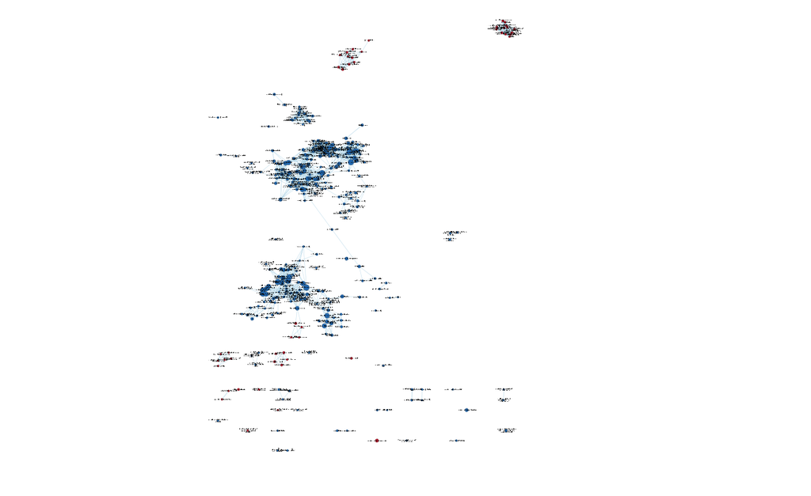

Figure 1. Network generated by EnrichmentMap

### Annotate your network - what parameters did you use to annotate the network. If you are using the default parameters make sure to list them as well.

The network was annotated using the default parameters in AutoAnnotate, using the GS_DESCR column, the MCL cluster algorithm, the similarity coefficient for determining the edge weights, and the WordCloud: Adjacent Words algorithm.

### Make a publication ready figure - include this figure with proper legends in your notebook.

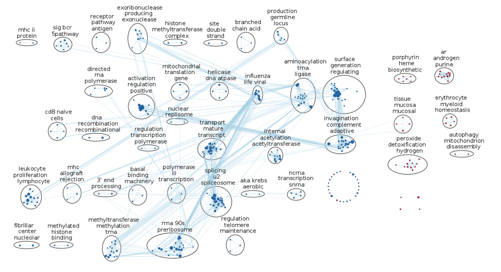

Figure 2. Network generated by AutoAnnotate

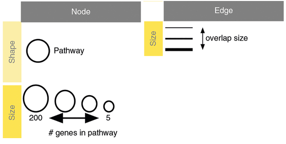

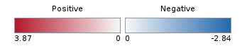

### Collapse your network to a theme network. What are the major themes present in this analysis? Do they fit with the model? Are there any novel pathways or themes?

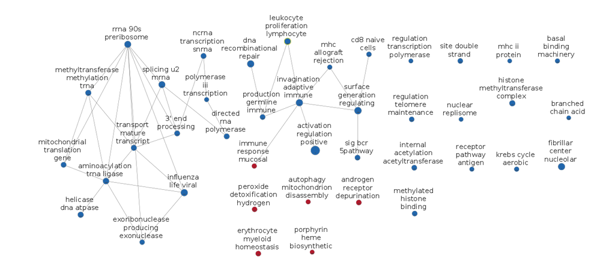

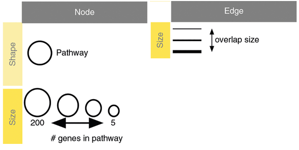

Lots of downregulation of RNA processing - this makes sense since the majority of the differentially expressed genes found in the previous assignments are downregulated, one would expect the cell’s machinery for the transcription of genes to be downregulated.

Immune response is both upregulated and downregulated. The single upregulated node seems to be mucosal immune response whereas the downregulated nodes are about immunoglobulin and lymphocyte-mediated immune response. The upregulation of mucosal immune response may be related to the initial immune response to IgIV[1](https://www.ncbi.nlm.nih.gov/pmc/articles/PMC5638328/).

Antibody and MHC-related words also stand out as relevant, given the context of the study. Their downregulation makes sense given the purpose of the treatment is to lower sensitivity in patients to transplants, thus allowing them to receive a transplant. Thus we see, in the downregulated nodes words such as CD8 cells, lymphocyte, leukocyte, antigen, receptor, etc. The cause of immune reactions to transplants is the MHC complex, which is bound by CD8 cells. This complex is at the heart of transplant rejection, so its downregulation seems to be in conformity with the hypothesis of the treatment.

Even though the study concluded that the treatment was not effective, it seems to have successfuly decreased transcription of transplant rejection-related genes.

### Present your results with the use of tables and screenshots. All figures should have appropriate figure legends.

#### If using figures create a figures directory in your repo and make sure all references to the figures are relative in your Rmarkdown notebook.

### Do the enrichment results support conclusions or mechanism discussed in the original paper? How do these results differ from the results you got from Assignment #2 thresholded methods

The authors point out that the protocol “did not decrease cPRA levels, the strength of anti-HLA antibodies determined by MFI values of Luminex single antigen beads, and the number of unacceptable antigens or increase the kidney transplant rate.” This is supported by the results: it is clear that the treatment is having some effect, in the sense that it is changing the expression of genes in an expected way, but the HLA levels measured by the researchers remained stable, contrary to what previous literature suggested. The authors point out that their patients were of a more severe case of sensitization, and so this may be partly simply due to the dosage not being enough to effect a change. They also report that their own analysis showed a significant decrease of B-cell and immunoglobulin related transcripts, which was replicated in this and previous analyses, but the patients still require additional treatment.

### Can you find evidence, i.e. publications, to support some of the results that you see. How does this evidence support your result?

Although the paper does not make explicit the mechanism for the IgIV + rituximab treatment, [previous literature](https://www.ncbi.nlm.nih.gov/pubmed/20110854) shows that it works by reducing HLA antibodies. Downregulation of immune system is visible in the results analysed here, but doesn’t seem to have been enough to effect a change in the sensitized patients. The authors report that despite efficient depletion of CD20 cells, the levels of donor-specific antibodies did not change for highly sensitized patients. The upregulation of mucosal immune response seems to point towards a reaction contrary to the purpose of the treatment, since it may have been triggered by the depleted immune system being more sensitive to bacteria. Although I could not find any other mention of this in the literature, Vo et al. point out in the paper mentioned above that 6 of their patients suffered viral infections after treatment, likely due to the depletion of their immune system.

### Choose a specific pathway or theme to investigate in more detail. Why did you choose this pathway or theme? Show the pathway or theme as a gene network or as a pathway diagram. Annotate the network or pathway with your original log fold expression values and p-values to show how it is effected in your model. (Hint: if the theme or pathway is not from database that has detailed mechanistic information like Reactome you can use apps like GeneMANIA or String to build the the interaction network.)

The pathway chosen was B CELL RECEPTOR SIGNALING PATHWAY%GOBP%GO:0050853, because most of the downregulation we see in the network is related to lymphocytes and immunity, as expected from the nature of the study. This seems to be the most relevant theme in this analysis.

We can see the ES distribution in the figure below.

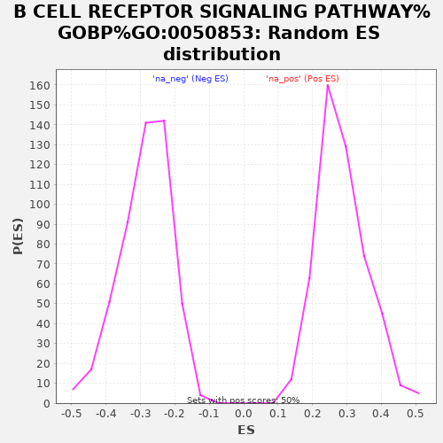

The pathway is shown below.

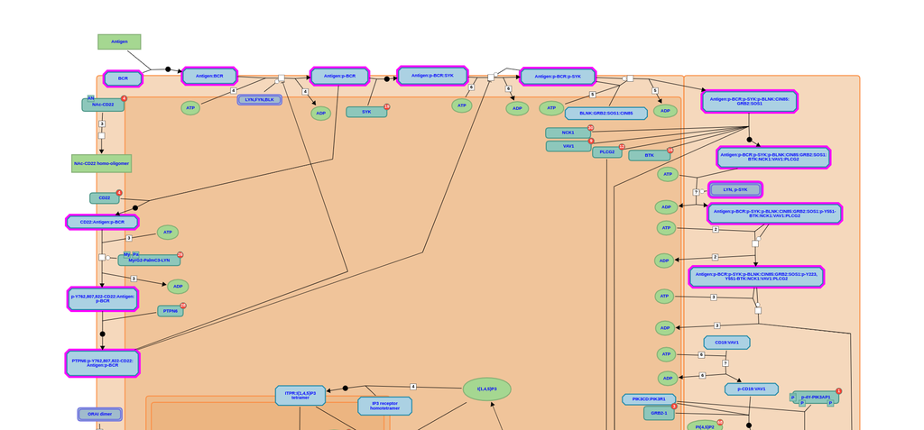

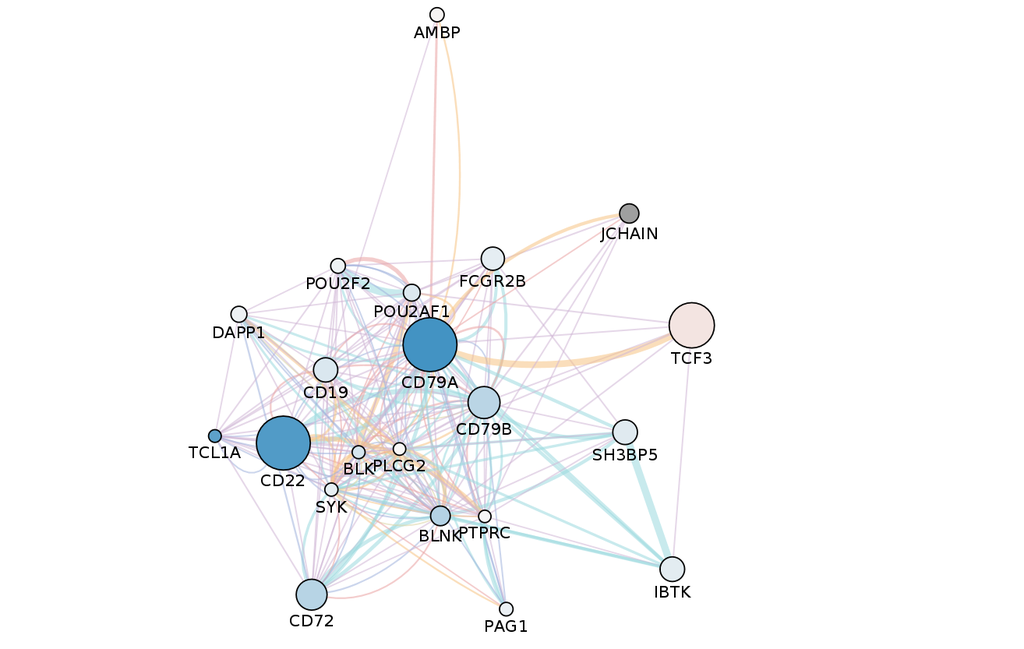

The above graph was obtained searching for CD79a in the GENEmania Cytoscape app, with the logFC values added as a continuous mapping to the nodes as their fill color.

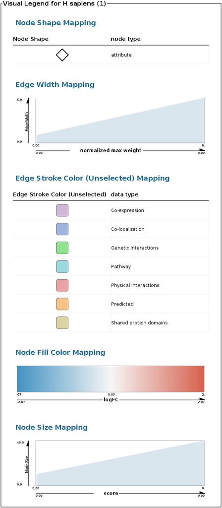

Legend for GENEmania

The logFC data was extracted from the analysis in the previous assignment, exported to a .csv file containing only gene symbols and corresponding log fold expression and imported into Cytoscape as a table, using the gene symbol as a key to join to the network table from GENEmania.

We can see downregulation of most genes interacting with CD79a except for TCF3, a transcription factor involved in cell fate determination during early B-cell differentiation. Its upregulation is quite small, so it may just be noise, although it’s possible that there is an increase of TCF3 transcription as the body’s response to the downregulation of other B-cell related trancripts.

# Previous assignments

## What are the control and test conditions of the dataset?

The controls are samples taken from untreated patients, whereas the test conditions are samples from patients treated with intravenous immune globulin (IVIG) (given on days 0 and 30) and rituximab (given on day 15).

## Why is the dataset of interest to you?

This dataset is of interest to me because I have a chronic kidney disease.

[output not shown]

We got the data, but the sample names are very long and hard to use, so we modify them, and add a “group” variable to keep track of the control vs treatment samples.

```r
filename <- Biobase::sampleNames(affyRaw)
pData(affyRaw)$filename <- filename
sampleNames <- sub("_.*", "", filename)
sampleNames(affyRaw) <- sampleNames
sampleNames(affyRaw) <- unlist(lapply(sampleNames, FUN = function(x){
  smpl <- GEOquery::Meta(GEOquery::getGEO(x))$title
  smpl <- gsub("patient ", "", smpl)
  smpl <- gsub("paitent ", "", smpl)
  smpl <- gsub("after treatment", "at", smpl)
  smpl <- gsub("before treatment", "bt", smpl)
  smpl <- gsub("untreated control", "uc", smpl)
  smpl <- gsub("(non-paired analysis)", "np", smpl)
  smpl <- gsub("(paired analysis)", "p", smpl)
  return(smpl)
}))

# add groups
pData(affyRaw)$group <- ifelse(grepl("at", sampleNames(affyRaw)),
                               "After Treatment", "Control")
pData(affyRaw)$group <- ifelse(grepl("bt", sampleNames(affyRaw)),
                               "Before Treatment", pData(affyRaw)$group)
```

We first get the MDS plot of our data to find outliers.

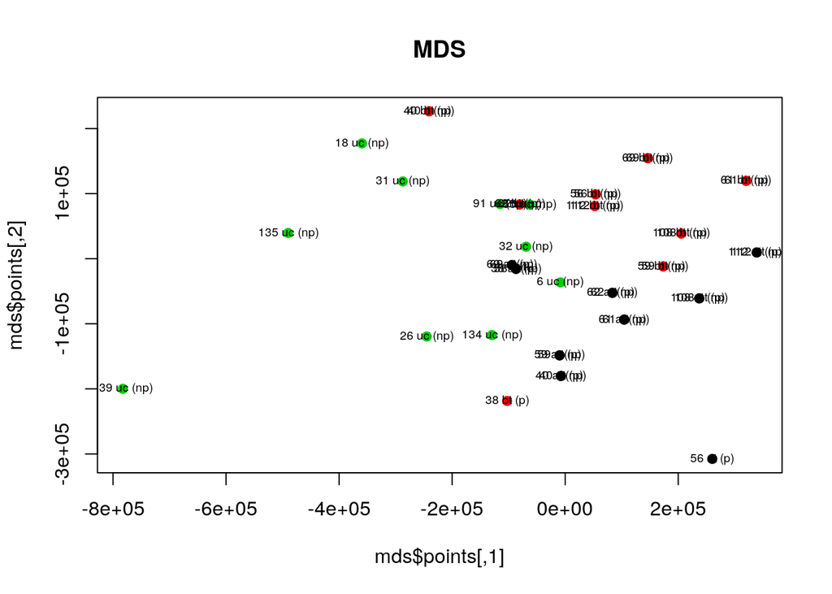

```r
mds <- cmdscale(dist(t(exprs(affyRaw))),eig=TRUE)
plot(mds$points,col=as.numeric(as.factor(pData(affyRaw)$group)),pch=19,main="MDS")
text(mds$points, labels=sampleNames(affyRaw), cex=0.6)
```

We remove the sample first.

[output not shown]

Now we reload the data.

[output not shown]

We have to tag everything again.

```r
filename <- Biobase::sampleNames(affyRaw)
pData(affyRaw)$filename <- filename
sampleNames <- sub("_.*", "", filename)
sampleNames(affyRaw) <- sampleNames
sampleNames(affyRaw) <- unlist(lapply(sampleNames, FUN = function(x){
  smpl <- GEOquery::Meta(GEOquery::getGEO(x))$title
  smpl <- gsub("patient ", "", smpl)
  smpl <- gsub("paitent ", "", smpl)
  smpl <- gsub("after treatment", "at", smpl)
  smpl <- gsub("before treatment", "bt", smpl)
  smpl <- gsub("untreated control", "uc", smpl)
  smpl <- gsub("(non-paired analysis)", "np", smpl)
  smpl <- gsub("(paired analysis)", "p", smpl)
  return(smpl)
}))

# add groups
pData(affyRaw)$group <- ifelse(grepl("at", sampleNames(affyRaw)),
                               "After Treatment", "Control")
pData(affyRaw)$group <- ifelse(grepl("bt", sampleNames(affyRaw)),
                               "Before Treatment", pData(affyRaw)$group)
```

Now we can see a box plot of our data.

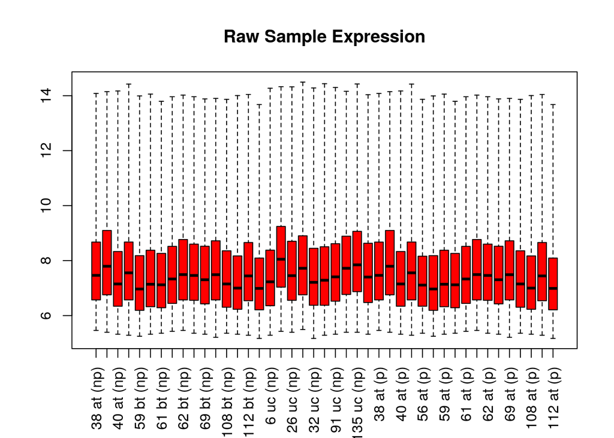

```r
boxplot(affyRaw, target="core", which="pm", col="red", names=sampleNames(affyRaw), main="Raw Sample Expression", las=3)
```

We can see the distribution has some samples that are slightly off the average. We’ll normalize it and plot it again.

```
## Background correcting
## Normalizing
## Calculating Expression
```

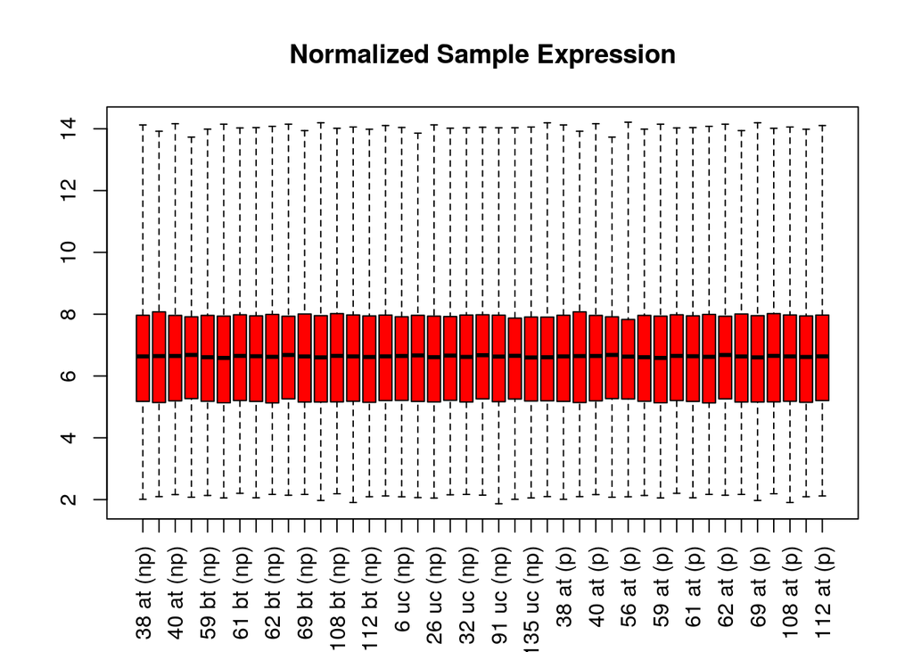

The data looks much cleaner now. We can compare the histograms.

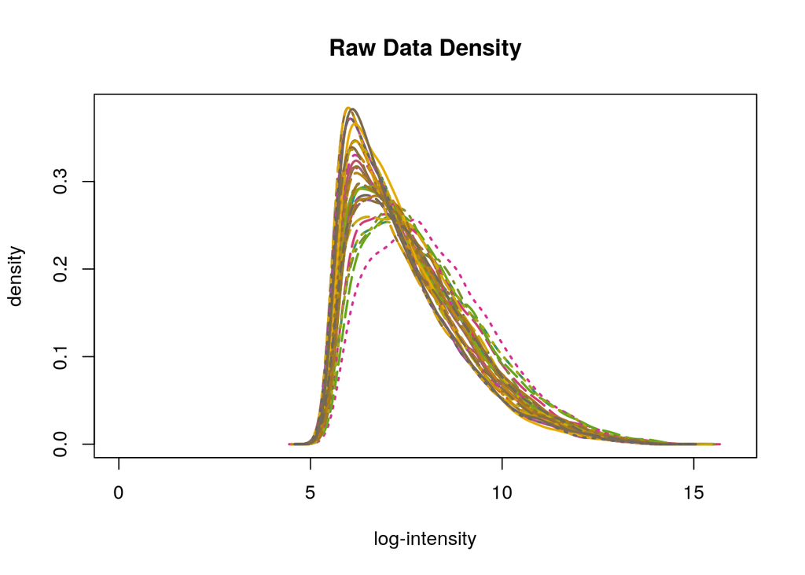

```r
hist(affyRaw, xlim=c(0,16), target="core", main="Raw Data Density", lwd=2)
```

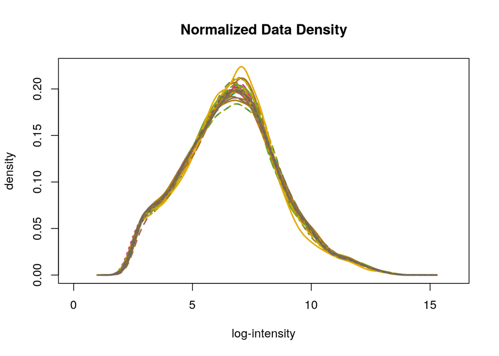

```r
hist(affyNorm, xlim=c(0,16), main="Normalized Data Density", lwd=2)
```

We still only have probeset IDs in our dataset, but fortunately there is an annotation package for this platform, which we can get.

```r
es <- affycoretools::annotateEset(affyNorm, pd.hugene.1.0.st.v1)
f <- Biobase::fData(es)
```

## Were there expression values that were not unique for specific genes? How did you handle these?

Yes, as the experiment was performed with microarrays, there are several probesets that map to the same gene. This is expected, and although averaging or adding them may be done, following the suggestion of [Obi Griffith in BioStars](https://www.biostars.org/p/51756/), we will leave them until later, in order to actually see the different probes during differential expression analysis, since it’s possible that we lose some significant data by trying to correct them at this stage (e.g. averaging could end up showing the gene as not differentially expressed, when in reality one of the probes is and the other is not).

## How many outliers were removed?

One sample was removed as an outlier since it was very far off in the MDS plot.

## How did you handle replicates?

There was only 1 replicate for each condition per sample.

## What is the final coverage of your dataset?

Originally we had 33297 probes, but after removing unmappable ones we have 25293.

### Introduction

#### Summary of the normalization and results done in the first assignment

In the previous assignment we explored the data from GSE31729, which is associated with the paper “Lack of effect in desensitization with intravenous immunoglobulin and rituximab in highly-sensitized patients” by Akalin et al. This dataset contains gene expression profiles of blood samples gathered with Affymetrix Human Gene 1.0 ST Array of transplant patients, and it’s trying to determine the effect of IVIG & rituximab on highly sensitized patients (the desired effect would be a desensitization, which would make it easier and safer for these patients to receive transplants).

In the previous analysis we removed an outlier sample (number 39) and normalized the data. We discovered a total of 8004 unmapped probes, which were removed, giving us a total of 25293 probes.

Before we start our DE analysis, we’ll clean up the data a bit with some steps that weren’t included in the last analysis: removing low-intensity probes, as well as unmapped and multiply-mapped probes.

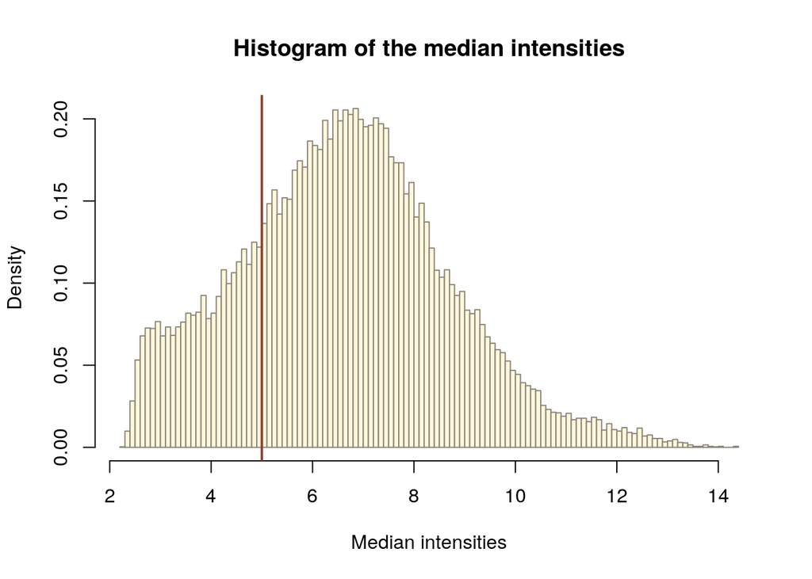

```r
# Load in data from previous analysis
es <- readRDS("Assignment_1_Data.Rds")

# Remove control and paired data, since we're only looking at before vs after
filteredEs <- es[, es$group != "Control"]

filteredEs <- filteredEs[, 17:34]
#filteredEs <- filteredEs[, 1:16]

# Get the median probe intensities
medians <- Biobase::rowMedians(Biobase::exprs(filteredEs))

# We set the threshold at 5, slightly below the peak
man_threshold <- 5
hist_res <- hist(medians, 100, col = "cornsilk", freq = FALSE,
                 main = "Histogram of the median intensities",
                 border = "antiquewhite4",
                 xlab = "Median intensities")
abline(v = man_threshold, col = "coral4", lwd = 2)
```

```r
# Get patient numbers in a separate column
patientNumbers <- substr(rownames(Biobase::pData(filteredEs)), 1,3)
patientNumbers <- trimws(patientNumbers, which = c("both"))
Biobase::pData(filteredEs)[,4] <- patientNumbers

# Get the Biobase::pData in its own variable
filteredEsNp <- Biobase::pData(filteredEs)
colnames(filteredEsNp)[4] <- "Patient"
colnames(filteredEsNp)[3] <- "Treatment"

# Filter out all transcripts that do not have intensities greater than the threshold in at least as many arrays as the smallest experimental group
# See https://www.bioconductor.org/packages/devel/workflows/vignettes/maEndToEnd/inst/doc/MA-Workflow.html#10_filtering_based_on_intensity
no_of_samples <- table(filteredEsNp$Treatment)
samples_cutoff <- min(no_of_samples)
idx_man_threshold <- apply(Biobase::exprs(filteredEs), 1,
                           function(x){
                          sum(x > man_threshold) >= samples_cutoff})
                          table(idx_man_threshold)
```

```
## idx_man_threshold
## FALSE  TRUE
##  7387 25910
```

```r
filteredEs <- subset(filteredEs, idx_man_threshold)

# Remove NA (unmapped probes)
filteredEs <- subset(filteredEs, !is.na(Biobase::fData(filteredEs)$SYMBOL))

# Remove multiple mappings
grouped <- dplyr::group_by(Biobase::fData(filteredEs), PROBEID)
summarized <- dplyr::summarize(grouped, matches = dplyr::n_distinct(SYMBOL))
filt <- dplyr::filter(summarized, matches > 1)
```

### Differential Expression analysis

#### Differential expression analysis with your normalized expression set from Assignment #1. Model design definition.

We’ll look at our MDS plot again.

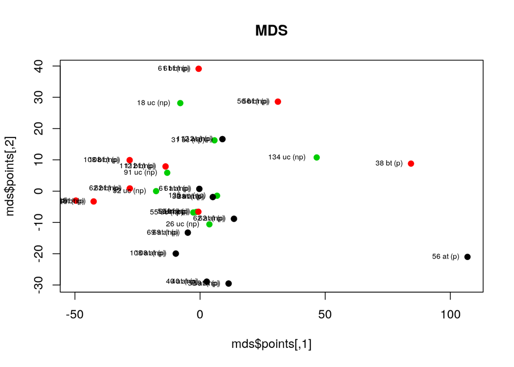

```r
mds <- cmdscale(dist(t(Biobase::exprs(es))),eig=TRUE)
plot(mds$points,col=as.numeric(as.factor(Biobase::pData(es)$group)),pch=19,main="MDS")
text(mds$points, labels=Biobase::sampleNames(es), cex=0.6, adj = 1.3)
```

We see some slight clustering of pre- and post-treatment samples. We’ll also use the patient number as a factor in our model since we need to account for sample similarity in that regard. We also note samples 38 and 56 which seem to be relatively isolated.

```r
# Factorize the grouping variables
groupsP = filteredEsNp$Patient
groupsT = filteredEsNp$Treatment
fp = factor(groupsP,levels=unique(filteredEsNp$Patient))
ft = factor(groupsT,levels=unique(filteredEsNp$Treatment))

# Create design matrix
pairedDesign = model.matrix(~ fp + ft)
fit = limma::lmFit(filteredEs,pairedDesign)
eb <- limma::eBayes(fit)
pValues <- eb$p.value[, 10]

# Get most DE genes
topfit <- limma::topTable(eb, coef=ncol(pairedDesign), adjust.method = "BH", number = nrow(Biobase::exprs(filteredEs)))
```

#### How many genes were significantly differentially expressed

We had a total of 2574 significantly differentially expressed genes.

#### What thresholds were used and why

The arbitrary but well-accepted threshold of 0.05 for P-value was used. Additionally, given that the paper used a threshold of log odds > 0, this was also used below (it was stored in the B column in the topTable output).

#### Which method was used and why

According to the limma documentation: >The first four methods (Bonferroni, Holm, Hochberg, Hommel) are designed to give strong control of the family-wise error rate. There seems no reason to use the unmodified Bonferroni correction because it is dominated by Holm’s method, which is also valid under arbitrary assumptions. Hochberg’s and Hommel’s methods are valid when the hypothesis tests are independent or when they are non-negatively associated (Sarkar, 1998; Sarkar and Chang, 1997). Hommel’s method is more powerful than Hochberg’s, but the difference is usually small and the Hochberg p-values are faster to compute. The “BH” (aka “fdr”) and “BY” method of Benjamini, Hochberg, and Yekutieli control the false discovery rate, the expected proportion of false discoveries amongst the rejected hypotheses. The false discovery rate is a less stringent condition than the family-wise error rate, so these methods are more powerful than the others.

The “BH” method was chosen as this seems to be generally the most appropriate for microarray data, as well as being less stringent. Additionally, the BH method was used in the original paper.

#### How many genes passed correction

A total of 0 genes passed correction. It should be noted that in the paper the authors also used log odds values, which would give 48 instead.

#### Amount of differentially expressed genes using a Volcano plot

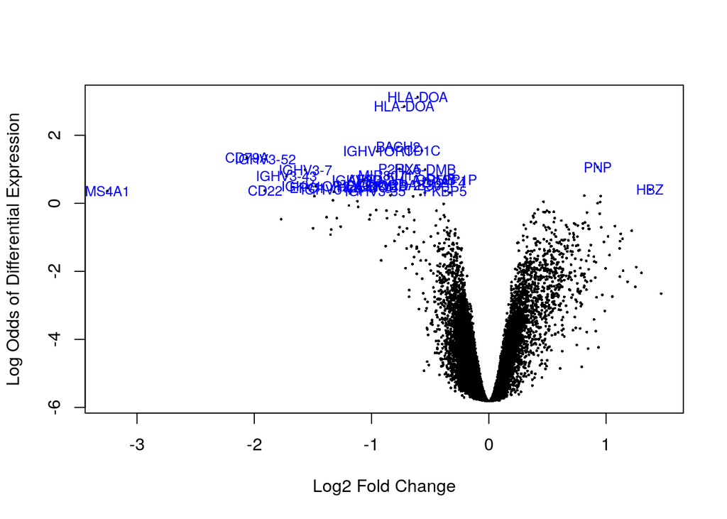

```r
# Get the volcano plot
limma::volcanoplot(eb, coef = 10, style = "B-statistic", highlight = 31, names = eb$genes$SYMBOL, xlab = "Log2 Fold Change", ylab = NULL, pch=16, cex=0.35)
```

In the plot we can see genes that are mentioned in the paper (in Table 3 and the “Whole Gene Expression Profiles Before and After Treatment” section) such as MS4A1, HLA-DOA, ADAM28, CD79a, CD79b, etc.

#### Visualization of top hits using a heatmap

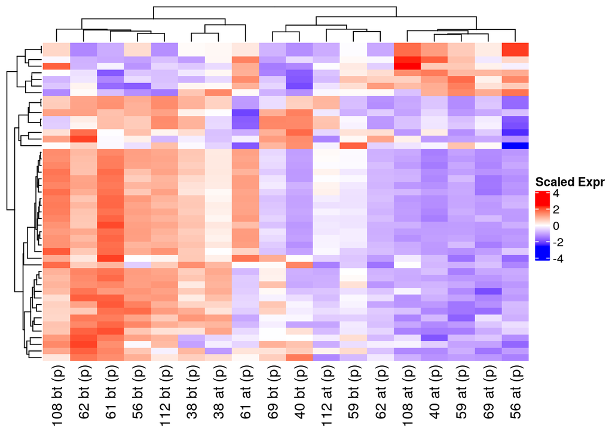

```r
# Get Top DE genes
top <- topfit[topfit$B > 0, ]

# Get heat map for the top 50 upregulated genes
heatmap_matrix <- Biobase::exprs(filteredEs)[rownames(Biobase::exprs(filteredEs)) %in% top$PROBEID, ]
heatmap_matrix <- t(scale(t(heatmap_matrix)))
dend <- dendsort::dendsort(hclust(dist(as.matrix(heatmap_matrix))))

if(min(heatmap_matrix) == 0){
    heatmap_col = circlize::colorRamp2(c( 0, max(heatmap_matrix)), c( "white", "red"))
} else {
    heatmap_col = circlize::colorRamp2(c(min(heatmap_matrix), 0, max(heatmap_matrix)), c("blue", "white", "red"))
}
current_heatmap <- ComplexHeatmap::Heatmap(as.matrix(heatmap_matrix),
                           show_row_dend = TRUE,
                           show_column_dend = TRUE,
                           col=heatmap_col,
                           show_column_names = TRUE,
                           show_row_names = FALSE,
                           show_heatmap_legend = TRUE,
                           cluster_rows = dend,
                           name="Scaled Expr"
)
current_heatmap
```

Sample 38 after treatment seems to cluster closer to the ones before treatment, which is strange but it makes sense that its closest neighbour is sample 38 before treatment. We note that this sample was slightly isolated in our MDS plot, which may explain this. A more vexing case is that of sample 61 after treatment, which clusters with unrelated pre-treatment samples, as well as 40 before treatment which does the opposite. It’s possible that this simply represents a lack of effect of the treatment on the patient.

### Thresholded over-representation analysis

#### Which method was used and why

In the paper the authors use the limma::romer function, with the Molecular Signatures Database as well as PBT gene sets from the University of Alberta, but their link to these sets returns a 404, so in the interest of verifying their results rather than simply trying to replicate them, as well as due to familiarity with the tool, gProfiler was chosen.

```r
gpAll <- gprofiler2::gost(as.vector(top$ID), organism = "hsapiens", correction_method = "fdr", sources = c("REAC", "WP"), domain_scope = "known")
gpAll$result
```

| query | significant | p_value | term_size | query_size | intersection_size | precision | recall | term_id | source | term_name | effective_domain_size | source_order | parents |
| --- | --- | --- | --- | --- | --- | --- | --- | --- | --- | --- | --- | --- | --- |
| query_1 | TRUE | 4.430226e-15 | 61 | 41 | 8 | 0.19512195 | 0.131147541 | REAC:R-HSA-5690714 | REAC | CD22 mediated BCR regulation | 60617 | 238 |  |
| query_1 | TRUE | 3.578110e-14 | 85 | 41 | 8 | 0.19512195 | 0.094117647 | REAC:R-HSA-983695 | REAC | Antigen activates B Cell Receptor (BCR) leading to generation of second messengers | 60617 | 138 |  |
| query_1 | TRUE | 4.390470e-13 | 62 | 41 | 7 | 0.17073171 | 0.112903226 | REAC:R-HSA-173623 | REAC | Classical antibody-mediated complement activation | 60617 | 332 |  |
| query_1 | TRUE | 5.759225e-13 | 69 | 41 | 7 | 0.17073171 | 0.101449275 | REAC:R-HSA-166786 | REAC | Creation of C4 and C2 activators | 60617 | 367 |  |
| query_1 | TRUE | 5.759225e-13 | 67 | 41 | 7 | 0.17073171 | 0.104477612 | REAC:R-HSA-2029481 | REAC | FCGR activation | 60617 | 764 |  |
| query_1 | TRUE | 1.065557e-12 | 77 | 41 | 7 | 0.17073171 | 0.090909091 | REAC:R-HSA-166663 | REAC | Initial triggering of complement | 60617 | 1031 |  |
| query_1 | TRUE | 1.287902e-12 | 799 | 41 | 12 | 0.29268293 | 0.015018773 | REAC:R-HSA-1280218 | REAC | Adaptive Immune System | 60617 | 108 |  |
| query_1 | TRUE | 1.287902e-12 | 81 | 41 | 7 | 0.17073171 | 0.086419753 | REAC:R-HSA-2029485 | REAC | Role of phospholipids in phagocytosis | 60617 | 1793 |  |
| query_1 | TRUE | 1.735301e-12 | 164 | 41 | 8 | 0.19512195 | 0.048780488 | REAC:R-HSA-983705 | REAC | Signaling by the B Cell Receptor (BCR) | 60617 | 1948 |  |
| query_1 | TRUE | 3.466484e-12 | 181 | 41 | 8 | 0.19512195 | 0.044198895 | REAC:R-HSA-198933 | REAC | Immunoregulatory interactions between a Lymphoid and a non-Lymphoid cell | 60617 | 1008 |  |

[output cut: 32 more lines]

#### What annotation data was used, which version, and why

Reactome and WikiPathways were used as data sources, to find which pathways were enriched in the differentially expressed genes. GO was attempted but the results were very vague and repetitive.

#### How many genesets were returned and their thresholds

With a threshold of p < 0.05, we got 42 genesets.

#### Comparison of down- vs up-regulated genes

```r
# Get top upregulated and downregulated genes
topdown = topfit[topfit$logFC < 0 & topfit$B > 0, ]
topup = topfit[topfit$logFC > 0 & topfit$B > 0, ]

gpUp <- gprofiler2::gost(as.vector(topup$ID), organism = "hsapiens", correction_method = "fdr", sources = c("REAC", "WP"), domain_scope = "known")
gpDown <- gprofiler2::gost(as.vector(topdown$ID), organism = "hsapiens", correction_method = "fdr", sources = c("REAC", "WP"), domain_scope = "known")

gpDown$result
```

| query | significant | p_value | term_size | query_size | intersection_size | precision | recall | term_id | source | term_name | effective_domain_size | source_order | parents |
| --- | --- | --- | --- | --- | --- | --- | --- | --- | --- | --- | --- | --- | --- |
| query_1 | TRUE | 9.612053e-16 | 61 | 35 | 8 | 0.22857143 | 0.131147541 | REAC:R-HSA-5690714 | REAC | CD22 mediated BCR regulation | 60617 | 238 |  |
| query_1 | TRUE | 7.779681e-15 | 85 | 35 | 8 | 0.22857143 | 0.094117647 | REAC:R-HSA-983695 | REAC | Antigen activates B Cell Receptor (BCR) leading to generation of second messengers | 60617 | 138 |  |
| query_1 | TRUE | 1.156819e-13 | 62 | 35 | 7 | 0.20000000 | 0.112903226 | REAC:R-HSA-173623 | REAC | Classical antibody-mediated complement activation | 60617 | 332 |  |
| query_1 | TRUE | 1.518386e-13 | 67 | 35 | 7 | 0.20000000 | 0.104477612 | REAC:R-HSA-2029481 | REAC | FCGR activation | 60617 | 764 |  |
| query_1 | TRUE | 1.518386e-13 | 69 | 35 | 7 | 0.20000000 | 0.101449275 | REAC:R-HSA-166786 | REAC | Creation of C4 and C2 activators | 60617 | 367 |  |
| query_1 | TRUE | 1.709635e-13 | 799 | 35 | 12 | 0.34285714 | 0.015018773 | REAC:R-HSA-1280218 | REAC | Adaptive Immune System | 60617 | 108 |  |
| query_1 | TRUE | 2.409622e-13 | 77 | 35 | 7 | 0.20000000 | 0.090909091 | REAC:R-HSA-166663 | REAC | Initial triggering of complement | 60617 | 1031 |  |
| query_1 | TRUE | 3.043726e-13 | 81 | 35 | 7 | 0.20000000 | 0.086419753 | REAC:R-HSA-2029485 | REAC | Role of phospholipids in phagocytosis | 60617 | 1793 |  |
| query_1 | TRUE | 3.799308e-13 | 164 | 35 | 8 | 0.22857143 | 0.048780488 | REAC:R-HSA-983705 | REAC | Signaling by the B Cell Receptor (BCR) | 60617 | 1948 |  |
| query_1 | TRUE | 7.600976e-13 | 181 | 35 | 8 | 0.22857143 | 0.044198895 | REAC:R-HSA-198933 | REAC | Immunoregulatory interactions between a Lymphoid and a non-Lymphoid cell | 60617 | 1008 |  |

[output cut: 27 more lines]

```r
gpUp$result
```

| query | significant | p_value | term_size | query_size | intersection_size | precision | recall | term_id | source | term_name | effective_domain_size | source_order | parents |
| --- | --- | --- | --- | --- | --- | --- | --- | --- | --- | --- | --- | --- | --- |
| query_1 | TRUE | 0.013354875 | 15 | 6 | 1 | 0.1666667 | 0.0666666667 | REAC:R-HSA-74259 | REAC | Purine catabolism | 60617 | 1574 |  |
| query_1 | TRUE | 0.013354875 | 13 | 6 | 1 | 0.1666667 | 0.0769230769 | REAC:R-HSA-74217 | REAC | Purine salvage | 60617 | 1576 |  |
| query_1 | TRUE | 0.013647146 | 23 | 6 | 1 | 0.1666667 | 0.0434782609 | REAC:R-HSA-8956321 | REAC | Nucleotide salvage | 60617 | 1393 |  |
| query_1 | TRUE | 0.014235216 | 32 | 6 | 1 | 0.1666667 | 0.0312500000 | REAC:R-HSA-8956319 | REAC | Nucleobase catabolism | 60617 | 1390 |  |
| query_1 | TRUE | 0.019333995 | 109 | 6 | 1 | 0.1666667 | 0.0091743119 | REAC:R-HSA-977225 | REAC | Amyloid fiber formation | 60617 | 132 |  |
| query_1 | TRUE | 0.019333995 | 87 | 6 | 1 | 0.1666667 | 0.0114942529 | REAC:R-HSA-3371556 | REAC | Cellular response to heat stress | 60617 | 300 |  |
| query_1 | TRUE | 0.019333995 | 93 | 6 | 1 | 0.1666667 | 0.0107526882 | REAC:R-HSA-15869 | REAC | Metabolism of nucleotides | 60617 | 1221 |  |
| query_1 | TRUE | 0.019333995 | 65 | 6 | 1 | 0.1666667 | 0.0153846154 | REAC:R-HSA-8873719 | REAC | RAB geranylgeranylation | 60617 | 1585 |  |
| query_1 | TRUE | 0.019333995 | 67 | 6 | 1 | 0.1666667 | 0.0149253731 | REAC:R-HSA-3371453 | REAC | Regulation of HSF1-mediated heat shock response | 60617 | 1692 |  |
| query_1 | TRUE | 0.019333995 | 10594 | 6 | 4 | 0.6666667 | 0.0003775722 | REAC:0000000 | REAC | REACTOME root term | 60617 | 2326 |  |

[output cut: 3 more lines]

We can see that the upregulated gene lists returns less results, with a few repetitive ones like Purine catabolism and Purine salvage, etc. This is in accordance with the paper which highlights significant downregulation of genes but not really upregulation. For the downregulated genes, we can see several B-cell-related genes, as well as Immunoglobulin (FCGR activation, Classical antibody-mediated complement activation), which are both mentioned in the paper as significantly enriched in their analysis.

#### References

References:

1. Martin Morgan (2018). BiocManager: Access the Bioconductor Project Package Repository. R package version 1.30.4. https://CRAN.R-project.org/package=BiocManager
2. Orchestrating high-throughput genomic analysis with Bioconductor. W. Huber, V.J. Carey, R. Gentleman, …, M. Morgan Nature Methods, 2015:12, 115.
3. Ritchie, M.E., Phipson, B., Wu, D., Hu, Y., Law, C.W., Shi, W., and Smyth, G.K. (2015). limma powers differential expression analyses for RNA-sequencing and microarray studies. Nucleic Acids Research 43(7), e47.
4. Hadley Wickham, Romain François, Lionel Henry and Kirill Müller (2020). dplyr: A Grammar of Data Manipulation. R package version 0.8.4. https://CRAN.R-project.org/package=dplyr
5. Gu, Z. (2016) Complex heatmaps reveal patterns and correlations in multidimensional genomic data. Bioinformatics.
6. Gu, Z. (2014) circlize implements and enhances circular visualization in R. Bioinformatics.
7. Liis Kolberg and Uku Raudvere (2019). gprofiler2: Interface to the ‘g:Profiler’ Toolset. R package version 0.1.8. https://CRAN.R-project.org/package=gprofiler2
8. Ryo Sakai (2015). dendsort: Modular Leaf Ordering Methods for Dendrogram Nodes. R package version 0.3.3. https://CRAN.R-project.org/package=dendsort